# Projekt R: Analiza danych

- Pokaż cały kod
- Ukryj cały kod
- Pokaż źródło

Autor

Sebastian

Utworzono

6 lutego 2026

# Importy

**Kod**

```r
library(tidyverse)
library(ggplot2)
```

# Zestaw danych Movies

Do projektu użyjemy zestawu danych ze strony internetowej *Kaggle* o nazwie *Movies*. Zaczniemy od zaimportowania naszych dancyh

**Kod**

```r
movies <- read_csv("movies.csv")
```

## Wizualizacja bazy danych

**Kod**

```r
movies %>%
  glimpse()
```

```
Rows: 7,668
Columns: 15
$ name     <chr> "The Shining", "The Blue Lagoon", "Star Wars: Episode V - The…
$ rating   <chr> "R", "R", "PG", "PG", "R", "R", "R", "R", "PG", "R", "PG", "P…
$ genre    <chr> "Drama", "Adventure", "Action", "Comedy", "Comedy", "Horror",…
$ year     <dbl> 1980, 1980, 1980, 1980, 1980, 1980, 1980, 1980, 1980, 1980, 1…
$ released <chr> "June 13, 1980 (United States)", "July 2, 1980 (United States…
$ score    <dbl> 8.4, 5.8, 8.7, 7.7, 7.3, 6.4, 7.9, 8.2, 6.8, 7.0, 6.1, 7.3, 5…
$ votes    <dbl> 927000, 65000, 1200000, 221000, 108000, 123000, 188000, 33000…
$ director <chr> "Stanley Kubrick", "Randal Kleiser", "Irvin Kershner", "Jim A…
$ writer   <chr> "Stephen King", "Henry De Vere Stacpoole", "Leigh Brackett", …
$ star     <chr> "Jack Nicholson", "Brooke Shields", "Mark Hamill", "Robert Ha…
$ country  <chr> "United Kingdom", "United States", "United States", "United S…
$ budget   <dbl> 1.9e+07, 4.5e+06, 1.8e+07, 3.5e+06, 6.0e+06, 5.5e+05, 2.7e+07…
$ gross    <dbl> 46998772, 58853106, 538375067, 83453539, 39846344, 39754601, …
$ company  <chr> "Warner Bros.", "Columbia Pictures", "Lucasfilm", "Paramount …
$ runtime  <dbl> 146, 104, 124, 88, 98, 95, 133, 129, 127, 100, 116, 109, 114,…
```

Jak widzimy nasza tabela posiada 7.668 wierszy i 15 kolumn. Widzimy też, że nazwy poszczególnych kolumn to: name, rating, genre, year, released, score, votes, director, writer, star, country, budget, gross, company, runtime.

Spójrzmy na naszą tabelę w osobnym *chunku*

**Kod**

```r
movies %>%
  tibble()
```

| name | rating | genre | year | released | score | votes | director | writer | star | country | budget | gross | company | runtime |
| --- | --- | --- | --- | --- | --- | --- | --- | --- | --- | --- | --- | --- | --- | --- |
| The Shining | R | Drama | 1980 | June 13, 1980 (United States) | 8.4 | 927000 | Stanley Kubrick | Stephen King | Jack Nicholson | United Kingdom | 19000000 | 46998772 | Warner Bros. | 146 |
| The Blue Lagoon | R | Adventure | 1980 | July 2, 1980 (United States) | 5.8 | 65000 | Randal Kleiser | Henry De Vere Stacpoole | Brooke Shields | United States | 4500000 | 58853106 | Columbia Pictures | 104 |
| Star Wars: Episode V - The Empire Strikes Back | PG | Action | 1980 | June 20, 1980 (United States) | 8.7 | 1200000 | Irvin Kershner | Leigh Brackett | Mark Hamill | United States | 18000000 | 538375067 | Lucasfilm | 124 |
| Airplane! | PG | Comedy | 1980 | July 2, 1980 (United States) | 7.7 | 221000 | Jim Abrahams | Jim Abrahams | Robert Hays | United States | 3500000 | 83453539 | Paramount Pictures | 88 |
| Caddyshack | R | Comedy | 1980 | July 25, 1980 (United States) | 7.3 | 108000 | Harold Ramis | Brian Doyle-Murray | Chevy Chase | United States | 6000000 | 39846344 | Orion Pictures | 98 |
| Friday the 13th | R | Horror | 1980 | May 9, 1980 (United States) | 6.4 | 123000 | Sean S. Cunningham | Victor Miller | Betsy Palmer | United States | 550000 | 39754601 | Paramount Pictures | 95 |
| The Blues Brothers | R | Action | 1980 | June 20, 1980 (United States) | 7.9 | 188000 | John Landis | Dan Aykroyd | John Belushi | United States | 27000000 | 115229890 | Universal Pictures | 133 |
| Raging Bull | R | Biography | 1980 | December 19, 1980 (United States) | 8.2 | 330000 | Martin Scorsese | Jake LaMotta | Robert De Niro | United States | 18000000 | 23402427 | Chartoff-Winkler Productions | 129 |
| Superman II | PG | Action | 1980 | June 19, 1981 (United States) | 6.8 | 101000 | Richard Lester | Jerry Siegel | Gene Hackman | United States | 54000000 | 108185706 | Dovemead Films | 127 |
| The Long Riders | R | Biography | 1980 | May 16, 1980 (United States) | 7.0 | 10000 | Walter Hill | Bill Bryden | David Carradine | United States | 10000000 | 15795189 | United Artists | 100 |

[output cut: 7658 more lines]

Przed przejściem do zapytań, dobrze by było wyczyścić dane z pozycji które są nieznane. Jak się okazuje ponad 2000 pozycji jest nieznanych dla kolumny `budget`. Na ten moment usuniemy tylko te pozycje które są nieznane dla `runtime`, `score` i `votes`

**Kod**

```r
movies <- movies %>%
  drop_na(runtime, score, votes)
```

Z ciekawości i dla sprawdzenia naszych danych użyjemy dodatkowo funkcji `summary`

**Kod**

```r
movies %>% summary()
```

```
     name              rating             genre                year
 Length:7661        Length:7661        Length:7661        Min.   :1980
 Class :character   Class :character   Class :character   1st Qu.:1991
 Mode  :character   Mode  :character   Mode  :character   Median :2000
                                                          Mean   :2000
                                                          3rd Qu.:2010
                                                          Max.   :2020

   released             score           votes           director
 Length:7661        Min.   :1.900   Min.   :      7   Length:7661
 Class :character   1st Qu.:5.800   1st Qu.:   9100   Class :character
 Mode  :character   Median :6.500   Median :  33000   Mode  :character
                    Mean   :6.391   Mean   :  88123
                    3rd Qu.:7.100   3rd Qu.:  93000
                    Max.   :9.300   Max.   :2400000

    writer              star             country              budget
 Length:7661        Length:7661        Length:7661        Min.   :     3000
 Class :character   Class :character   Class :character   1st Qu.: 10000000
 Mode  :character   Mode  :character   Mode  :character   Median : 20750000
                                                          Mean   : 35614797
                                                          3rd Qu.: 45000000
                                                          Max.   :356000000
                                                          NA's   :2169
     gross             company             runtime
 Min.   :3.090e+02   Length:7661        Min.   : 55.0
 1st Qu.:4.532e+06   Class :character   1st Qu.: 95.0
 Median :2.018e+07   Mode  :character   Median :104.0
 Mean   :7.851e+07                      Mean   :107.3
 3rd Qu.:7.602e+07                      3rd Qu.:116.0
 Max.   :2.847e+09                      Max.   :366.0
 NA's   :183
```

## Zapytania

#### Zapytanie 1

Chcemy znaleźć najdłużej trwający film, tak żeby nasza tabela pokazywała nam jego tytuł, długość trwania oraz studio produkcji oraz kraj wyprodukowania

**Kod**

```r
movies %>%
  filter(runtime == max(runtime, na.rm = TRUE)) %>%
  select(
    Tytuł = name,
    "Czas trwania" = runtime,
    Studio = company,
    Kraj = country
    )
```

| Tytuł | Czas trwania | Studio | Kraj |
| --- | --- | --- | --- |
| The Best of Youth | 366 | BiBi Film | Italy |

#### Zapytanie 2

Jako drugie pytanie chcemy jaki jest najlepszy film (jaki jest najwyżej oceniany film) względem danego gatunku. Chcemy w naszej tabeli widzieć gatunek, tytuł i jego ocenę

**Kod**

```r
movies %>%
  select(
    Tytuł = name,
    Gatunek = genre,
    Ocena = score
    ) %>%
  group_by(Gatunek) %>%
  slice_max(Ocena, n = 1) %>%
  arrange(desc(Tytuł)) %>%
  tibble()
```

| Tytuł | Gatunek | Ocena |
| --- | --- | --- |
| The Thing | Horror | 8.1 |
| The Shawshank Redemption | Drama | 9.3 |
| The Piano Player | Romance | 7.8 |
| The Dark Knight | Action | 9.0 |
| The Business of Show Business | History | 8.3 |
| Spirited Away | Animation | 8.6 |
| Schindler's List | Biography | 8.9 |
| Pulp Fiction | Crime | 8.9 |
| Parasite | Comedy | 8.6 |
| Memento | Mystery | 8.4 |

[output cut: 10 more lines]

#### Zapytanie 3

**Kod**

```r
movies %>%
  filter(str_detect(company, 'Walt '), genre == 'Animation') %>%
  slice_max(score, n = 5)
```

| name | rating | genre | year | released | score | votes | director | writer | star | country | budget | gross | company | runtime |
| --- | --- | --- | --- | --- | --- | --- | --- | --- | --- | --- | --- | --- | --- | --- |
| The Lion King | G | Animation | 1994 | June 24, 1994 (United States) | 8.5 | 970000 | Roger Allers | Irene Mecchi | Matthew Broderick | United States | 4.50e+07 | 1083720877 | Walt Disney Pictures | 88 |
| Coco | PG | Animation | 2017 | November 22, 2017 (United States) | 8.4 | 417000 | Lee Unkrich | Lee Unkrich | Anthony Gonzalez | United States | 1.75e+08 | 807817888 | Walt Disney Pictures | 105 |
| Toy Story | G | Animation | 1995 | November 22, 1995 (United States) | 8.3 | 913000 | John Lasseter | John Lasseter | Tom Hanks | United States | 3.00e+07 | 394436586 | Walt Disney Pictures | 81 |
| Toy Story 3 | G | Animation | 2010 | June 18, 2010 (United States) | 8.2 | 776000 | Lee Unkrich | John Lasseter | Tom Hanks | United States | 2.00e+08 | 1066970811 | Walt Disney Pictures | 103 |
| Beauty and the Beast | G | Animation | 1991 | November 22, 1991 (United States) | 8.0 | 424000 | Gary Trousdale | Linda Woolverton | Paige O'Hara | United States | 2.50e+07 | 424967620 | Walt Disney Pictures | 84 |
| Aladdin | G | Animation | 1992 | November 25, 1992 (United States) | 8.0 | 382000 | Ron Clements | Ron Clements | Scott Weinger | United States | 2.80e+07 | 504050219 | Walt Disney Pictures | 90 |
| Ratatouille | G | Animation | 2007 | June 29, 2007 (United States) | 8.0 | 660000 | Brad Bird | Brad Bird | Brad Garrett | United States | 1.50e+08 | 623726085 | Walt Disney Pictures | 111 |
| Zootopia | PG | Animation | 2016 | March 4, 2016 (United States) | 8.0 | 450000 | Byron Howard | Byron Howard | Ginnifer Goodwin | United States | 1.50e+08 | 1024121104 | Walt Disney Pictures | 108 |

## Wykresy

#### Wykres 1

Jako wykres pierwszy stworzymy histogram obrazujący rozkład ilości filmów względem długości. Jak wiemy większość filmów jest długości 1 godziny i 30 minut. Spójrzmy, czy wykres odzwierciedla rzeczywistość

**Kod**

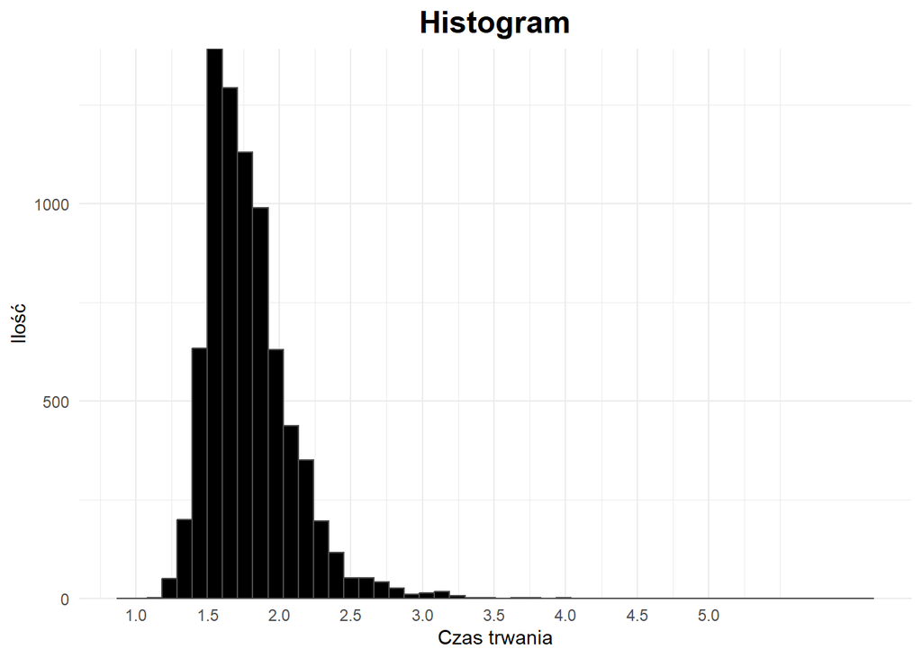

```r
movies %>%
  ggplot() +
  geom_histogram(aes(runtime/60), color = "grey30", bins = 50, fill = "black") +
  scale_x_continuous(breaks = seq(1, 5, by = 0.5))+
  scale_y_continuous(expand = c(0,0)) +
  labs(x = "Czas trwania", y = "Ilość", title = "Histogram") +
  theme_minimal() +
  theme(plot.title = element_text(hjust = 0.5, size = 17, face = "bold"))
```

Istotnie, najwięcej filmów jest długości 1.5 godziny (1 godziny i 30 minut).

#### Wykres 2

Jako drugi wykres, użyjemy *Box-plot* (wykres skrzynkowy) która przedstawia rozkład danych. Będziemy badać jaki jest rozkład ocen względem poszczególnego gatunku

**Kod**

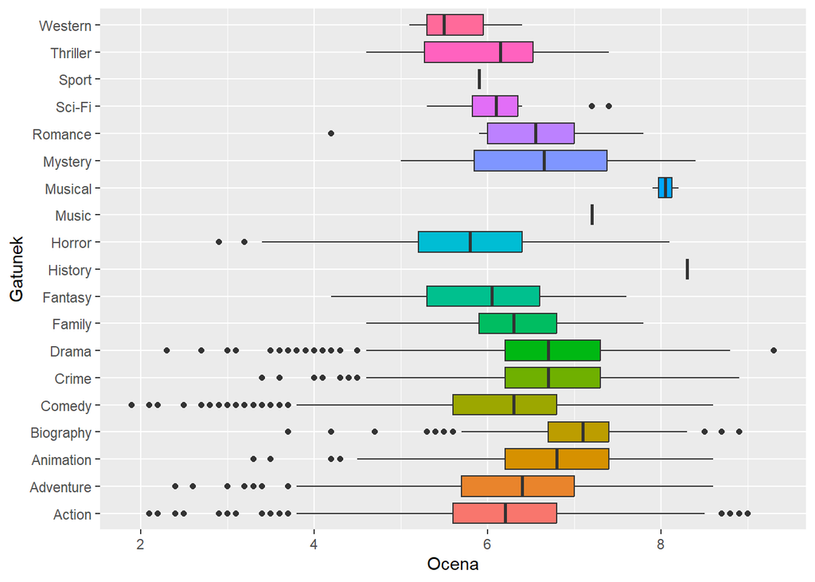

```r
movies %>%
  ggplot() +
  aes(x = genre, y = score, fill = genre) +
  geom_boxplot() +
  coord_flip() +
  labs(x = "Gatunek", y = "Ocena") +
  theme(legend.position = "none")
```

#### Wykres 3

Wykres trzeci spróbuje odpowiedzieć nam na pytanie, czy budżet wpływa na ocenę filmu. Czy przeznaczanie wysokich kosztów na produkcje filmów powoduje że widownia odbiera te filmy pozytywnie. Jak pamiętamy, w naszym zestawie danych ponad 2000 pozycji ma nieznany budżet, więc przed przystąpieniem do tworzenia wykresu, usuniemy te pozycje

**Kod**

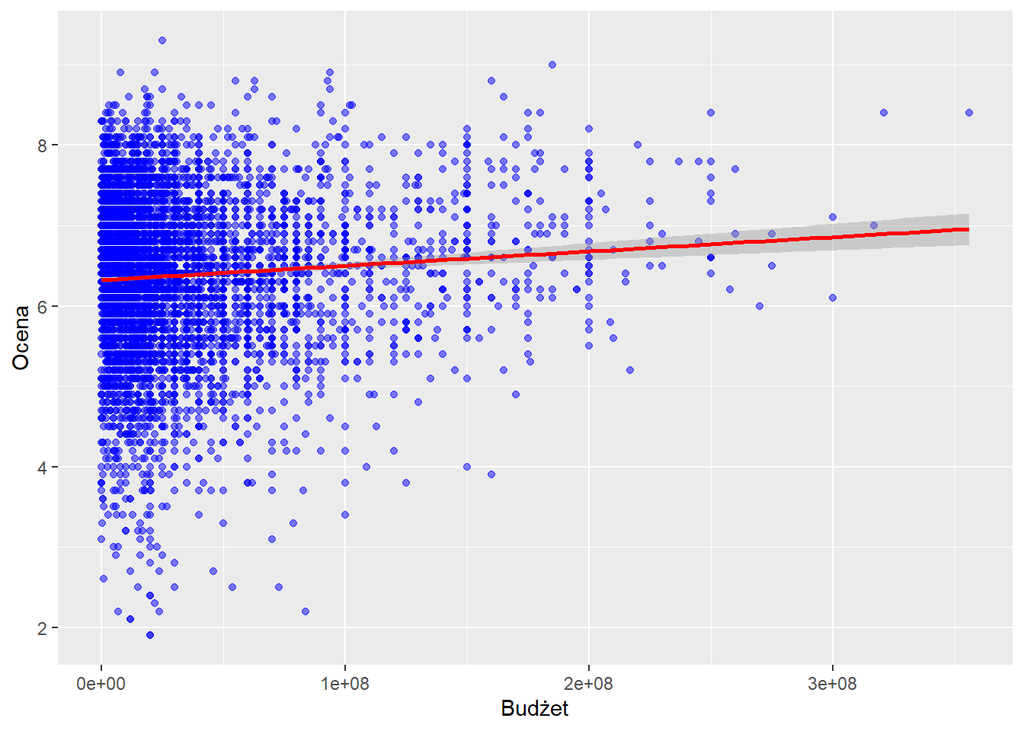

```r
movies %>%
  drop_na(budget) %>%
  ggplot(aes(x = budget, y = score)) +
  geom_point(alpha = 0.5, color = "blue") +
  geom_smooth(method = "lm", color = "red") +
  labs(x = "Budżet", y = "Ocena")
```

Jak widzimy, tendencja jest wzrostowa, to znaczy że rzeczywiście, przeznacznie wysokich kosztów na film jest na ogół wyżej oceniany.